# BPB3: BayesPI-BAR version 3 package User Guide

# Demo5:

# Applying bpb3 on Genome-wide Sequencing Data of Follicular Lymphoma Patients by using clustered-PWMs with two-levels approach

**Running by command line method**

First-level analysis: run_clusterPWM_cmd_fl.py  
Second-level analysis: run_selected_pwms_from_clusterPWM_cmd_fl.py

## Aim and pipeline flow

In demo5, the same data from demos 3 and 4 are analyzed again by using a two-level approach with clustered PWMs, to predict TF binding affinity changes that are significantly altered by mutations in follicular lymphoma (FL) patients. In the first-level analysis (run_clusterPWM_cmd_fl.py): ~737 clustered PWMs generated by abc4pwm package are used in the calculation, both the computation (e.g., clustered PWMs are used in foreground and background calculations) and the results are similar to that in the Demo4. However, all tasks are performed by bpb3 command lines instead of upload a single configure file. In the second-level analysis (run_selected_pwms_from_clusterPWM_cmd_fl.py): the top ranked N (e.g., 25) clustered PWMs for each mutation block are selected, then the PWMs grouped in these clusters (e.g., ~592 PWMs) are extracted and used to predict TF binding affinity changes that are significantly altered by mutation block in FL. In this way, more detailed information of TF binding and mutation changes will be revealed. For example, both positive and negative TF binding affinity changes are predicted by the second-level analysis in demo5, from where most results are missed in the demo4. The CPU time requirement for completing the two-levels analysis (demo5) is between the full PWM (demo3) and the clustered PWMs (demo4) calculations. Thus, the two-levels approach can be attractive for dealing with a large number of input data such as thousands of PWMs and hundreds mutation blocks.

## Run job

**Run job**  
demo5_fl_cohort_small_cluster4pwm_cmd/sbatch job_bpb3

```bash
sbatch job_bpb3
```

Job script:

run_clusterPWM_cmd_fl.py (first-level analysis)  
run_selected_pwms_from_clusterPWM_cmd_fl.py (second-level analysis)

**Main process**  
The main processes are stored in Slurm file, example:

```
######################################################
# The first-level analysis (run_clusterPWM_cmd_fl.py)
######################################################
T-test

Export at  ../../final_demo_data/demo5_fl_cohort_small_cluster4pwm_cmd/out/regions.bed
Read , ../../final_demo_data/demo5_fl_cohort_small_cluster4pwm_cmd/out/mussd_blocks/blocks_summary.tsv
Adjust P-values by Bonferroni correction in high mutation blocks test

Calculating delta-dbA values...

Mutation count distribution:
     number of mutations     probability
     3              0.058823529411764705
     4              0.11764705882352941
     5              0.11764705882352941
     6              0.11764705882352941
     7              0.11764705882352941
     9              0.11764705882352941
     ...

736 total PWMs
../../final_demo_data/demo5_fl_cohort_small_cluster4pwm_cmd/out/foreground/block_1_18_60987833_60988302/ddba/ddba_integrated_using_mean_ddba.tsv : 9 mutations,  736 PWMs
736 total PWMs

Positive PWMs at 0.05 bonferroni significance:
     abc4pwm_quality_assessed_out_seed5~bZIP~out~10~repres~10_rep.mlp   bonferroni p: 9.698334202911714e-05     #cases: 8 / 9
     abc4pwm_quality_assessed_out_seed5~C2H2_ZF~out~22~repres~22_rep.mlp    bonferroni p: 0.0010021872039803505     #cases: 6 / 9
     abc4pwm_quality_assessed_out_seed5~Forkhead~out~16~repres~16_rep.mlp   bonferroni p: 0.03695475257018746   #cases: 9 / 9

Negative PWMs at 0.05 bonferroni significance:
     abc4pwm_quality_assessed_out_seed5~SMAD~out~2~repres~2_rep.mlp     bonferroni p: 2.9929455471303854e-06    #cases: 8 / 9
     abc4pwm_uncertain_pwms~16_FOXL1_4_from_FOXL1_jolma_full_M423-Forkhead.mlp  bonferroni p: 0.005990835478453819  #cases: 8 / 9
     abc4pwm_uncertain_pwms~48_MEIS2_4_from_Meis2_jolma_DBD_M168-Homeodomain.mlp    bonferroni p: 0.007008929445330146  #cases: 8 / 9
     abc4pwm_uncertain_pwms~48_MEIS3_3_from_MEIS3_jolma_DBD_M166-Homeodomain.mlp    bonferroni p: 0.009560183664687954  #cases: 8 / 9
     abc4pwm_uncertain_pwms~32_ZEB1_known1_from_ZEB1_1_from_AREB6_transfac_M00412-Homeodomain.mlp   bonferroni p: 0.025928694669070763  #cases: 8 / 9
     abc4pwm_uncertain_pwms~6_NFE2L2_2_from_Nrf-2_transfac_M00821-bZIP.mlp  bonferroni p: 0.049361817560367505  #cases: 7 / 9


########################################################################
```

[output cut: 43 more lines]

```
     16_FOXL1_4_from_FOXL1_jolma_full_M423-Forkhead.mlp     uncorrected p: 7.710682658002321e-05    #cases: 7 / 9
     16_FOXK1_4_from_Foxk1_jolma_DBD_M448-Forkhead.mlp  uncorrected p: 0.00014266440993913405   #cases: 5 / 9
     5_CEBPB_known3_from_CEBP_1_from_CorEBP_transfac_M00159-bZIP.mlp    uncorrected p: 0.0007005999995891079    #cases: 6 / 9
     0_FOXA_known6_from_FOXA2_2_from_Foxa2_jaspar_MA0047.2-Forkhead.mlp     uncorrected p: 0.0014884330108712583    #cases: 5 / 9
     16_FOXJ3_2_from_FOXJ3_jolma_DBD_M419-Forkhead.mlp  uncorrected p: 0.0023823579390769263    #cases: 7 / 9
     28_NKX2-6_1_from_Nkx2-6_bulyk_cell08-3437.1-Homeodomain.mlp    uncorrected p: 0.0030789661244267465    #cases: 3 / 9
     41_NKX2-2_2_from_Nkx2-2_bulyk_cell08-2823.1-Homeodomain.mlp    uncorrected p: 0.003238524573078161     #cases: 4 / 9
     0_FOXA_known5_from_FOXA1_2_from_FOXA1_jaspar_MA0148.1-Forkhead.mlp     uncorrected p: 0.004143090421516073     #cases: 5 / 9
     4_FOXJ2_1_from_FOXJ2_transfac_M00422-Forkhead.mlp  uncorrected p: 0.005512213527075125     #cases: 6 / 9
     16_HNF4_known8_from_HNF4_5_from_HNF4,-COUP_transfac_M00967-Nuclear_receptor.mlp    uncorrected p: 0.0058785304744752125    #cases: 6 / 9
     0_FOXA_known2_from_FOXA1_1_from_HNF3alpha_transfac_M00724-Forkhead.mlp     uncorrected p: 0.006744534175241563     #cases: 5 / 9
     8_FOXI1_1_from_HFH3-(FOXI1)_transfac_M00289-Forkhead.mlp   uncorrected p: 0.008079242074901804     #cases: 5 / 9

Filtering results by gene expression for block block_0_18_60986372_60987028 ...
Filtering results by gene expression for block block_1_18_60987833_60988302 ...
```

**Data input**

```
# Gene expression data of control samples:
final_demo_data/demo5_fl_cohort_small_cluster4pwm_cmd/normal_gcb_counts/
|-- SRR834983.sorted.only_counts.tsv
|-- SRR834984.sorted.only_counts.tsv
|-- SRR834985.sorted.only_counts.tsv
`-- SRR834986.sorted.only_counts.tsv

# Patient specific mutations (vcf format) and gene expression data (*_expression.tsv)
final_demo_data/demo5_fl_cohort_small_cluster4pwm_cmd/patient_data/
|-- DO27859
|   |-- DO27859_expression.tsv
|   `-- icgc_mutations_on_18.tsv
|-- DO52653
|   |-- DO52653_expression.tsv
|   `-- icgc_mutations_on_18.tsv
|-- DO52656
|-- DO52669
|-- DO52676
|-- DO52677
|-- DO52680
|-- DO52681
|-- DO52685
|-- DO52689
|-- DO52694

# Clustered PWMs by applying abc4pwm on 1772 human PWMs when considering DNA binding domain (DBE) information:
final_demo_data/demo5_fl_cohort_small_cluster4pwm_cmd/abc4pwm_quality_assessed_out_seed5/
├── A.T_hook_factors
├── ARID_domain_factors
├── C2CH_THAP_type_ZF
│   └── out
│       ├── 0
│       │   ├── 0_AP1_known1_from_AP1_2_from_AP-1_transfac_M00172-C2CH_THAP_type_ZF.mlp
│       │   ├── 0_AP1_known2_from_AP1_3_from_AP-1_transfac_M00173-C2CH_THAP_type_ZF.mlp
│       │   ├── 0_AP1_known4_from_AP1_5_from_AP-1_transfac_M00188-C2CH_THAP_type_ZF.mlp
│       │   └── repres
│       │       └── 0_rep.mlp
│       ├── 1
│       │   ├── 1_AP1_known10_from_AP1_1_from_AP1_jaspar_MA0099.2-C2CH_THAP_type_ZF.mlp
│       │   ├── 1_AP1_known7_from_AP1_8_from_AP-1_transfac_M00924-C2CH_THAP_type_ZF.mlp
│       │   ├── 1_AP1_known9_from_AP1_10_from_AP-1_transfac_M00926-C2CH_THAP_type_ZF.mlp
│       │   └── repres
│       │       └── 1_rep.mlp
│       ├── 2
│       │   ├── 2_AP1_known5_from_AP1_6_from_AP-1_transfac_M00199-C2CH_THAP_type_ZF.mlp
│       │   ├── 2_AP1_known8_from_AP1_9_from_AP-1_transfac_M00925-C2CH_THAP_type_ZF.mlp
 ...

# If PWMs with low cluster quality scores based on abc4pwm, then they are grouped in a folder labeled as uncertain_pwm:
final_demo_data/demo5_fl_cohort_small_cluster4pwm_cmd/abc4pwm_uncertain_pwms/
├── 0_AP1_known3_from_AP1_4_from_AP-1_transfac_M00174-C2CH_THAP_type_ZF.mlp
├── 0_ARHGEF12_1_from_IRC900814_bulyk_sc09-primary-Unknown.mlp
├── 0_BPTF_1_from_FAC1_transfac_M00456-Unknown.mlp
├── 0_BRCA1_known1_from_BRCA1_1_from_BRCA1:USF2_transfac_M01082-Unknown.mlp
├── 0_COMP1_1_from_COMP1_transfac_M00057-Unknown.mlp
 ...
```

**Data output**

```
# Results of the first-level analysis:
final_demo_data/demo5_fl_cohort_small_cluster4pwm_cmd/out/
|-- background
|   |-- background_mutation_pos.bed
|   |-- bayespi_bar_result
|   |-- possible_background_blocks_restricted.bed
|   |-- possible_background_block_starts.bed
|   |-- randomly_selected_blocks_alt.fasta
|   |-- randomly_selected_blocks.bed
|   `-- randomly_selected_blocks_ref.fasta
|-- demo5_fl_cohort_small_cluster4pwm_cmd_bpb3.log_1654256760.0383558
|-- demo5_fl_cohort_small_cluster4pwm_cmd_bpb3.log_1655281733.3790848
|-- differentially_expressed_genes.txt
|-- foreground
|   |-- block_0_18_60986372_60987028
|   `-- block_1_18_60987833_60988302
|-- make_background.sh
|-- mussd_blocks
|   |-- block_0_18_60986372_60987028_alt.fasta
|   |-- block_0_18_60986372_60987028.bed
|   |-- block_0_18_60986372_60987028_mutations.tsv
|   |-- block_0_18_60986372_60987028_ref.fasta
|   |-- block_1_18_60987833_60988302_alt.fasta
|   |-- block_1_18_60987833_60988302.bed
|   |-- block_1_18_60987833_60988302_mutations.tsv
|   |-- block_1_18_60987833_60988302_ref.fasta
|   |-- blocks_summary.tsv
|   |-- mutations_in_regions.tsv
|   |-- mutations_summary.tsv
|   `-- patients_summary.tsv
|-- normal_median_patient_rpkm.tsv
|-- regions.bed
|-- run_mussd.sh
|-- significant_blocks.txt
`-- tumor_median_patient_rpkm.tsv

# Results of the second-level analysis:
final_demo_data/demo5_fl_cohort_small_cluster4pwm_cmd/bpb3_by_selected_pwm_from_cluster4pwm/
├── block_0_18_60986372_60987028
│   ├── ddba
```

[output cut: 32 more lines]

```
    ├── rankings
    │   ├── block_1_18_60987833_60988302_patient_10_18_60987807_60988326_ranking.tsv
    │   ├── block_1_18_60987833_60988302_patient_1_18_60987807_60988326_ranking.tsv
    │   ├── block_1_18_60987833_60988302_patient_2_18_60987807_60988326_ranking.tsv
    │   ├── block_1_18_60987833_60988302_patient_3_18_60987807_60988326_ranking.tsv
    │   ├── block_1_18_60987833_60988302_patient_4_18_60987807_60988326_ranking.tsv
    │   ├── block_1_18_60987833_60988302_patient_6_18_60987807_60988326_ranking.tsv
    │   ├── block_1_18_60987833_60988302_patient_7_18_60987807_60988326_ranking.tsv
    │   ├── block_1_18_60987833_60988302_patient_8_18_60987807_60988326_ranking.tsv
    │   └── block_1_18_60987833_60988302_patient_9_18_60987807_60988326_ranking.tsv
    ├── result.tsv
    ├── result_filtered.tsv
    ├── result_gene_names.tsv
    ├── result_plot.png
    └── snp_id2snp.tsv
```

**Predicted TFs with significant binding affinity changes due to mutation block**  
**1. Output by the first-level analysis:**

Here, similar as demo4, the binding affinity of transcription factors including FOXL1 and MEIS3 was negatively affected in the mutation block.

| direction | pwm_name | bonferroni_p | affected_cases | total_cases |
| --- | --- | --- | --- | --- |
| Negative | abc4pwm_uncertain_pwms~16_FOXL1_4_from_FOXL1_jolma_full_M423-Forkhead.mlp | 0.0059908 | 8 | 9 |
| Negative | abc4pwm_uncertain_pwms~48_MEIS3_3_from_MEIS3_jolma_DBD_M166-Homeodomain.mlp | 0.0095602 | 8 | 9 |
| Negative | abc4pwm_uncertain_pwms~32_ZEB1_known1_from_ZEB1_1_from_AREB6_transfac_M00412-Homeodomain.mlp | 0.0259287 | 8 | 9 |

**Figure 1. Predicted TFs with significant binding affinity changes due to mutation block (first-level analysis)**  
File in: final_demo_data/demo5_fl_cohort_small_cluster4pwm_cmd/out/foreground/block_1_18_60987833_60988302/result_plot.png

Similar as result in demo 4, the result_plot shows TFs with significant binding affinity changes due to a mutation block (block_1_18_60987833_60988302) located at promoter of BCL2 gene. The binding affinity of three transcript factors, including FOXL1 and MEIS3, are negatively affected by this mutation block in most of patients.

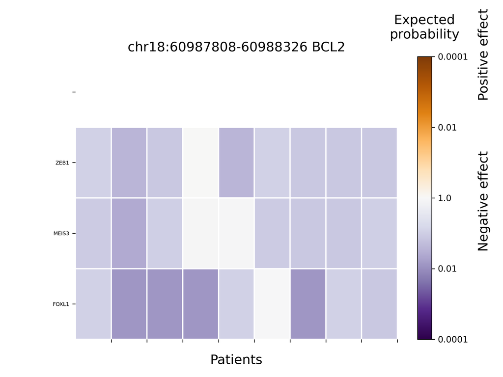

**Figure 1. result_plot**

**2. Output by the second-level analysis:**  
**Table 2**: One example of final results from the second-level analysis for predicting TFs bind affinity changes at promoter regions of differential expressed genes (DEG). final_demo_data/demo5_fl_cohort_small_cluster4pwm_cmd/bpb3_by_selected_pwm_from_cluster4pwm/block_1_18_60987833_60988302/result_filtered.tsv

similar as demo4 and the first-level analysis, the binding affinity of transcription factors including FOXL1 was negatively affected in the same mutation block.

| direction | pwm_name | uncorrected_p | affected_cases | total_cases |
| --- | --- | --- | --- | --- |
| Positive | 2_AP3_1_from_AP-3_transfac_M00690-C2CH_THAP_type_ZF.mlp | 0.0000126 | 2 | 9 |
| Positive | 8_SOX17_2_from_Sox17_jaspar_MA0078.1-HMG.mlp | 0.0006394 | 2 | 9 |
| Positive | 13_DBP_3_from_DBP_jolma_full_M372-bZIP.mlp | 0.0016192 | 1 | 9 |
| Positive | 3_ATF3_known3_from_CREB1_2_from_CREB_transfac_M00113-bZIP.mlp | 0.0016192 | 1 | 9 |
| Positive | 5_ATF3_known12_from_CREB1_8_from_CREB_transfac_M00916-bZIP.mlp | 0.0016192 | 1 | 9 |
| Positive | 21_POU2F2_known8_from_POU_1_from_OCT-x_transfac_M00210-Homeodomain.mlp | 0.0016192 | 1 | 9 |
| Positive | 7_ZNF784_1_from_ZNF784_jolma_full_M53-C2H2_ZF.mlp | 0.0016192 | 1 | 9 |
| Positive | 20_NKX3-1_1_from_Nkx3-1_transfac_M00451-Homeodomain.mlp | 0.0064062 | 2 | 9 |
| Positive | 2_TFAP2_known1_from_TFAP2_1_from_AP-2_transfac_M00189-bHSH.mlp | 0.0075474 | 5 | 9 |
| Negative | 4_FOXC1_2_from_FOXC1_jaspar_MA0032.1-Forkhead.mlp | 0.0000000 | 6 | 9 |
| Negative | 34_ZEB1_known2_from_ZEB1_2_from_AREB6_transfac_M00413-Homeodomain.mlp | 0.0000034 | 8 | 9 |
| Negative | 16_FOXL1_4_from_FOXL1_jolma_full_M423-Forkhead.mlp | 0.0000771 | 7 | 9 |
| Negative | 16_FOXK1_4_from_Foxk1_jolma_DBD_M448-Forkhead.mlp | 0.0001427 | 5 | 9 |
| Negative | 5_CEBPB_known3_from_CEBP_1_from_CorEBP_transfac_M00159-bZIP.mlp | 0.0007006 | 6 | 9 |
| Negative | 16_FOXJ3_2_from_FOXJ3_jolma_DBD_M419-Forkhead.mlp | 0.0023824 | 7 | 9 |
| Negative | 4_FOXJ2_1_from_FOXJ2_transfac_M00422-Forkhead.mlp | 0.0055122 | 6 | 9 |

**Figure 2. Predicted TFs with significant binding affinity changes due to mutation block (second-level analysis)**  
File in: final_demo_data/demo5_fl_cohort_small_cluster4pwm_cmd/bpb3_by_selected_pwm_from_cluster4pwm/block_1_18_60987833_60988302/result_plot.png

The result_plot shows TFs with significant binding affinity changes due to a mutation block (block_1_18_60987833_60988302) located at promoter of BCL2 gene. Similar to the first-level analysis, the transcript factor FOXL1 and ZEB1 were identified to be negatively affected in binding affinity. Importantly, more detailed information of TF binding and mutation changes have been revealed in the second level analysis, including more transcript factors with both negative and positive binding affinity changes were predicted.

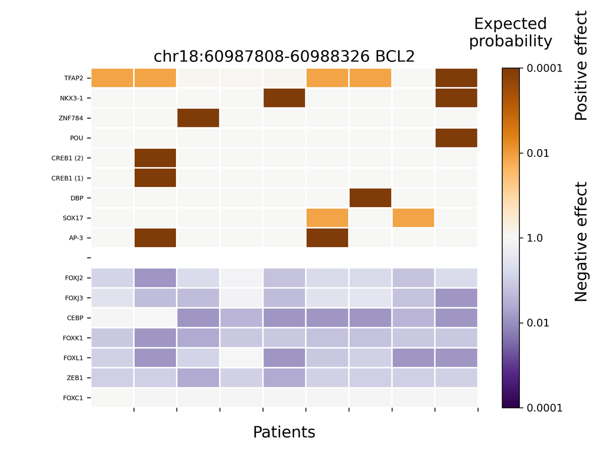

Figure 2. result_plot

**CPU requirement**

- MaxRSS: 82 MB
- Running time (first-level analysis): 41 min
- Running time (second-level analysis): 18 min

## Python code I (first-level analysis): a command line version of bpb3 pipeline

run_clusterPWM_cmd_fl.py

```python
import os
import glob
import sys
from bpb3.script.script_high.other import common
import time
#this script is used to evaluate effect of TF binding affinity changes due to DNA sequence mutations based on clustered PWMs from abc4pwm - first level analysis
#Here, most of bpb3 command line functions and parameter configures are shown in the same file
#
########Project main path parameters ##############
#Project Output path
out_data_folder = '../../final_demo_data/demo5_fl_cohort_small_cluster4pwm_cmd/out/'
common.check_folder(out_data_folder)
patient_data_folder = os.path.join(out_data_folder, '../',"patient_data")
normal_rnaseq_folder = os.path.join(out_data_folder,'../', "normal_gcb_counts")
project_name= 'demo5_fl_cohort_small_cluster4pwm_cmd'

#find patient muation files
patient_mut_files = []
for pf in glob.glob(os.path.join(patient_data_folder, "D*/")):
      patient_mut_files.append(os.path.join(pf, "icgc_mut*.tsv"))

#Genome path
genome_folder=os.path.abspath("../../final_demo_data/genome_data/hg19")
genome_fasta_file=  os.path.join(genome_folder, "human_g1k_v37_decoy.fasta")
gene_annotation_file= os.path.join(genome_folder, "gencode.v19.annotation.gtf")
gene_length_file =  os.path.join(genome_folder, "gene_lengths.tsv")


# output folders for mussd
mussd_result_folder=os.path.join(out_data_folder, 'mussd_blocks')
foreground_folder = os.path.join(out_data_folder, "foreground")
background_folder = os.path.join(out_data_folder, "background")
background_pwm_folder = os.path.join(out_data_folder, "pwm_for_background")

#Input gene expression folder and files
normal_count_files =  glob.glob(os.path.join(normal_rnaseq_folder, "*.only_counts.tsv"))
if len(normal_count_files)<1:
    print('Normal count file, ', normal_rnaseq_folder, ' not find!')
    exit(1)
donor_count_files = glob.glob(os.path.join(patient_data_folder, "D*/D*expression.tsv"))
if len(donor_count_files)<1:
    print('Tumor count file, ', donor_count_files, ' not find!')
    exit(1)

#Setup logger file
logging =common.setup_logger(out_data_folder,project_name, time.time())
logging.info("")

# make cluster pwms
#  Generate tempary pwms based on clustered and uncertain clustered PWMs ############
in_clustered_pwms_path=os.path.join(out_data_folder,'../')
in_clustered_pwms_folder_name='abc4pwm_quality_assessed_out_seed5'
in_uncertain_pwms_folder_name='abc4pwm_uncertain_pwms'
out_tmp_pwms_folder_name='tmp_pwm'
top_ranked_TF_from_clusteredPWM= 15

# folder with PWM models for TF binding affinity
#pwm_folder = os.path.join("../../public_data/pwm")
pwm_folder=os.path.join(in_clustered_pwms_path,out_tmp_pwms_folder_name)

#0. prepare clustered PWMs file for bpb3
cmd='bpb3 make_cluster4pwm --in_pwm_path ' + in_clustered_pwms_path +  \
        ' --in_clustered_pwm_folder ' +  in_clustered_pwms_folder_name + \
        ' --out_file_folder ' + out_tmp_pwms_folder_name + \
        ' --in_uncertain_pwm_folder ' + in_uncertain_pwms_folder_name

result_code=os.system(cmd)
if result_code != 0:
      print("bpb3 make_cluster4pwm failed. See message in the console to find what went wrong.")
      exit(1)
logging.info('Export at %s', os.path.join(in_clustered_pwms_path, out_tmp_pwms_folder_name))
pwm_folder=os.path.join(out_data_folder,'../',out_tmp_pwms_folder_name)


##############BPB3 pipeline parameters in each STEP ############################
#1. Differential gene expression options
differentially_expressed_genes_file = os.path.join(out_data_folder, "differentially_expressed_genes.txt")
group1_str='tumor'
group2_str='normal'
#Export file path
group1_median_rpkm_file = os.path.join(out_data_folder, group1_str + "_median_patient_rpkm.tsv")
group2_median_rpkm_file = os.path.join(out_data_folder, group2_str +"_median_patient_rpkm.tsv")

# maximum Kolmogorov-Smirnov test P value to consider genes as differentially expressed
differential_expression_p = 0.05
# whether to do quantile normalization of RPKM values, True or False
differential_expression_quantile_normalization = True
# whether to do log transformation of RPKM values, True or False
differential_expression_log_transform = True
# whether to do z-score transformation of RPKM values, True or False
differential_expression_z_score_transform = False
# minimum fold change of [quantile normalized] RPKM to consider genes as differentially expressed. None to disable
differential_expression_min_fold_change = None
#export full expression data
isExportAll = True
#test_method 1 for T-test
test_method=1
#minimum median RPKM in each group
minimum_median_RPKM=0  #1.0

# 2. Region of interest selection options
# number of base pairs to take upstream of TSS
upstream_size = 1000
# number of base pairs to take downstream of TSS
downstream_size = 1000
#Export file path or selected enhancer regions file
regions_file = os.path.join(out_data_folder, "regions.bed")

# Here, we do not use bpb3 function to extract a specified TSS regions, but manually input a bed format region file
# for DNA muatation enrichment and further TF binding affinity change significance test
#regions_file='../../public_data/mr_test/in/mr_intersect_enhancer_regions_chr18noChr.tsv'

# 3. MuSSD options
#in this example, we include all patiaints and all available mutations in the regions
# minimum number of patients in a hot mutation region
min_patients_in_block = 3
# minimum number of mutations in a hot mutation region
min_block_size = 3
# maximum distance between mutations in a hot mutation region
cluster_distance = 30
block_distance=500
# number of base pairs to add to the left and right side of a mutation block when extracting sequences
block_flank = 25

#4. P values for significant muation blocks
p_value_for_significant_blocks=0.001
mussd_command_file=os.path.join(out_data_folder, 'run_mussd.sh')
pval_correction=True
significant_blocks_file = os.path.join(out_data_folder, "significant_blocks.txt")

# 5. BayesPI-BAR options
# chemical potentials to use
chemical_potentials = "none -10 -13 -15 -18 -20"
# sequence shuffling iterations for dbA calculation
shuffling_iterations = 10000
#Parallel option path
parallel_options_file =  os.path.abspath(os.path.join(os.path.dirname(__file__), "parallel_options.txt"))
```

```python
# 6. Background model options
# max rank of a PWM file in the foreground results to include in the background model
max_ranking_for_background = 30
resampling_iterations = 10
gene_samples = 8
background_shuffling_iterations = 1000
background_command_file = os.path.join(out_data_folder, "make_background.sh")

# 7. mutation signature definition for generating background mutations, set to None to disable
mutation_signature_file = None  # "../../data/signature_7.tsv"
# set to True to use tumor mutations from patients as background mutations, False otherwise.
# This and the mutation signature are mutually exclusive.
# In both are disabled, uniform mutations will be generated
tumor_mutations_as_background = True

# Results selection options for significant affinity changes
# P value for ranksum test in the output
affinity_change_p_value = 0.05
pval_correction4affinity=True

#8. True or False parameters to run the bpb3, by either enable  or disable one of bpb3 steps
runDiffExp= True
runRegionsFile=True
runMussd= True
runHighMutBlocks= True
runBayesPiBAR= True
runBackgroundModel= True
runBlockSignificance= True

filterTFbyGene=True
runRemoveTempFile= True


############Usually, below lines do not need to be changed in order to run it on a new data set ##############

################START CALC ################
# 1. Differential gene expression
if runDiffExp:
 logging.info("Step 1: Computing differentially expressed genes")
 result_code = os.system("bpb3 differential_expression " +
                                " --group_2_count_files " + " ".join(normal_count_files) +
                                " --group_1_count_files " + " ".join(donor_count_files) +
                                " --gene_lengths " + gene_length_file +
                                " --output_file " + differentially_expressed_genes_file +
                                " --output_group_1_rpkm " + group1_median_rpkm_file +
                                " --output_group_2_rpkm " + group2_median_rpkm_file +
                                " --p_value " + str(differential_expression_p) +
                                " --test_method " + str(test_method) +
                                " --quantile_normalization" * differential_expression_quantile_normalization +
                                " --log_transform" * differential_expression_log_transform +
                                " --z_score" * differential_expression_z_score_transform +
                                " --output_all_values " * isExportAll +
                                (" --min_medianRPKM " + str(minimum_median_RPKM)
                                 if minimum_median_RPKM is not None else "") +
                                (" --min_fold_change " + str(differential_expression_min_fold_change)
                                 if differential_expression_min_fold_change is not None else ""))
 if result_code !=0:
       logging.info("Error in differential expresssion ")
       exit(1)

 logging.info('Export at %s ', differentially_expressed_genes_file )
else :
 logging.info('Skip step 1: differential gene expression analysis %s ', differentially_expressed_genes_file)


#2. Make regions of interest near promoters of differentially expressed genes
if runRegionsFile:
  cmd0="bpb3 gene_regions " +\
          " --gene_annotation " + gene_annotation_file +\
          " --transform_chrom" \
          " --output_file " + regions_file + \
          " --selected_genes " + differentially_expressed_genes_file + \
          " --upstream_size " + str(upstream_size) + \
          " --downstream_size " + str(downstream_size)
  result_code=os.system(cmd0)
  if result_code !=0:
       logging.info("Error in bpb3 gene_regions ")
       exit(1)
  else:
        logging.info('Export at %s ', regions_file )
else:
  logging.info('Skip step 2 regions export, but use selected regions for MUSSD %s  ', regions_file)

if runMussd:
 # 3. Run MuSSD
 logging.info("")
 logging.info("Step 3: Calculating mutation blocks with MuSSD")
 if not os.path.exists(mussd_result_folder):
   cmd_head='#!/bin/bash'
   cmd ="bpb3 mussd --patient_mutations " + " ".join(patient_mut_files) + " \\\n\t" + \
                   " --result_folder " + mussd_result_folder +  " \\\n\t" + \
                   " --genome " + genome_fasta_file +  " \\\n\t" + \
                   " --min_patients_in_block " + str(min_patients_in_block) +  " \\\n\t" + \
                   " --block_flank " + str(block_flank) +  " \\\n\t" + \
                   " --min_block_size " + str(min_block_size) +  " \\\n\t" + \
                   " --cluster_distance " + str(cluster_distance) +  " \\\n\t" + \
                   " --block_distance " + str(block_distance) + "\\\n\t" + \
                   " --regions " + regions_file
   with open(mussd_command_file,'w') as f:
       f.write(cmd_head + "\n" + cmd + "\n")
   f.close()
   #if input VCF files too many then have to run it in bash
   result_code= os.system("bash "+ mussd_command_file)
   if result_code !=0:
       #print(cmd)
       logging.info("Error in mussd ")
       exit(1)

   logging.info('Export at %s ', mussd_result_folder)
   logging.info("Information about patients is in the file %s", os.path.join(mussd_result_folder,
                                                                                  "patients_summary.tsv"))
   logging.info("Information about mutations is in the file %s", os.path.join(mussd_result_folder,
                                                                                   "mutations_summary.tsv"))
   logging.info("Information about found mutation blocks is in the file %s", os.path.join(mussd_result_folder,
                                                                                            "blocks_summary.tsv"))
 else:
   logging.info("MuSSD result is already present, skipping step 3")

 logging.info("There are %d patients in the mutation dataset", len(patient_mut_files))
else:
 logging.info('Skip step 3 MuSSD %s ', mussd_result_folder)
```

```python
if runHighMutBlocks:
 # 4. Select blocks that are mutated significantly more than average
 #significant_blocks_file = os.path.join(out_data_folder, "significant_blocks4mr_enhancer_regions.txt")
 logging.info("")
 logging.info("Step 4: Selecting blocks that are mutated more than average")
 result_code = os.system("bpb3 highly_mutated_blocks " +
                            " --blocks_folder " + mussd_result_folder +
                            " --p_value " + str(p_value_for_significant_blocks) +
                            " --output_file " + significant_blocks_file +
                            " --correctPval " * pval_correction )
 if result_code !=0:
       logging.info("Error in highly mutated blocks ")
       exit(1)

 logging.info('Export at %s ', significant_blocks_file )
else:
 logging.info('Skip step 4 highly_mutated_blocks test %s ', significant_blocks_file )


if os.stat(significant_blocks_file).st_size ==0:
  logging.info('No significant mutation blocks find, in P< %s ', str(p_value_for_siginificant_blocks) )
  logging.info('Program stop!!')
  exit(1)


#Read  significant mutation blocks
significant_block_tags = frozenset(common.read_lines(significant_blocks_file))
logging.info("%d blocks have significantly more mutations than expected: %s", len(significant_block_tags),
                 ", ".join(significant_block_tags))

#if runBayesPiBAR:
 # 5. Compute foreground for each significant block
logging.info("")
logging.info("Step 5: Running BayesPI-BAR on patient-specific mutation blocks")

common.check_folder(foreground_folder)
block_res_folders=[]
for i, block_tag in enumerate(significant_block_tags):
        block_res_folder = os.path.join(foreground_folder, block_tag)
        ref_seq = os.path.join(mussd_result_folder, block_tag + "_ref.fasta")
        alt_seq = os.path.join(mussd_result_folder, block_tag + "_alt.fasta")
        block_res_folders.append(block_res_folder)
        if os.path.exists(block_res_folder):
            logging.info("The foreground output for block %s [%d of %d] already exists. BayesPI-BAR will now check its "
                         "consistency and recompute the broken or missing data ", block_tag, i + 1,
                         len(significant_block_tags))
        else:
            logging.info("BayesPI-BAR will now compute the delta-dbA scores and rankings for block %s [%d of %d]",
                         block_tag, i + 1, len(significant_block_tags))
        if runBayesPiBAR:
           result_code = os.system("bpb3 bayespi_bar " +
                                " --reference_sequences " + ref_seq +
                                " --alternate_sequences " + alt_seq +
                                " --pwm_folder " + pwm_folder +
                                " --chemical_potentials " + chemical_potentials +
                                " --iterations " + str(shuffling_iterations) +
                                " --result_folder " + block_res_folder +
                                " --max_rank " + str(max_ranking_for_background) +
                                " --reuse_output" +
                                " @" + parallel_options_file)

           if result_code !=0:
              logging.info("Error in bayespi bar ")
              exit(1)

           logging.info('Export at %s', block_res_folder )
        else:
           logging.info('Skip step 5 bayePI-BAR %s ' , block_res_folder)

if runBackgroundModel:
 # 6. Compute the background
 logging.info("")
 logging.info("Step 6: Computing the background model")
 logging.info("Creating shell file with the command to compute the background: %s", background_command_file)
 result_code = os.system("bpb3 choose_background_parameters " +
                            " --blocks_folder " + mussd_result_folder +
                            " --foreground_folder " + foreground_folder +
                            " --background_pwm_folder " + background_pwm_folder +
                            " --output_file " + background_command_file +
                            " --block_ids " + " ".join(significant_block_tags) +
                            " --genome " + genome_fasta_file +
                            " --regions " + regions_file +
                            " --pwm_folder " + pwm_folder +
                            " --iterations " + str(background_shuffling_iterations) +
                            " --chemical_potentials " + chemical_potentials +
                            " --background_output_folder " + background_folder +
                            " --block_resample_iterations " + str(resampling_iterations) +
                            " --block_samples_to_take " + str(gene_samples) +
                            " --reuse_output" +
                            " --max_rank " + str(max_ranking_for_background) +
                            ((" --mutation_signature " + mutation_signature_file)
                             if mutation_signature_file is not None else "") +
                            (" --background_mutations %s" %
                             os.path.join(mussd_result_folder, "mutations_in_regions.tsv")) *
                            tumor_mutations_as_background +
                            " @" + parallel_options_file)

 if result_code !=0:
       logging.info("Error in choose background parameters ")
       exit(1)

 logging.info('Export at %s ', background_command_file )

 if os.path.exists(background_folder):
    logging.info("The folder with background output already exists. The background computation script will now "
                     "check its consistency and recompute the broken or missing data")
 else:
    logging.info("The background computation script will now compute the background delta-dbA score distributions %s ", background_command_file)

 result_code = os.system("bash " + background_command_file)
 if result_code != 0:
     logging.info("Background model computation failed. See messages in the console to find what went wrong.")
     exit(1)
```

```python
 logging.info("Export at %s ", background_folder)

else:
 logging.info('Skip step 6 background_computation %s ', background_folder)


if runBlockSignificance:
 # 7. Run significance tests
 logging.info("")
 logging.info("Step 7: Significance tests will now be computed comparing background and foreground delta-dbA "
                 "distributions for each PWM in each mutation block")

 for block_tag in significant_block_tags:
        block_folder = os.path.join(foreground_folder, block_tag)
        result_file = os.path.join(block_folder, "result.tsv")
        print( block_tag, ":" )
        result_code = os.system("bpb3 affinity_change_significance_test " +
                                " --background_folder " + os.path.join(background_folder, "bayespi_bar_result") +
                                " --foreground_folder " + block_folder +
                                " --output_file " + result_file +
                                " --max_rank " + str(max_ranking_for_background) +
                                " --p_value " + str(affinity_change_p_value) +
                                " --pval_correction " * pval_correction4affinity)
        if result_code !=0:
            logging.info("Error in affinity change significance test %s", block_tag)
            exit(1)

        logging.info("The table of significantly affected PWMs for block %s is stored in the file %s ", block_tag,
                     result_file)

if filterTFbyGene:
 # 8. Filter results by TF gene expression
 logging.info("")
 logging.info("Step 8: PWMs corresponding to the non-expressed TFs will now be removed from the results")

 for block_tag in significant_block_tags:
        block_folder = os.path.join(foreground_folder, block_tag)
        result_file = os.path.join(block_folder, "result.tsv")
        filtered_result_file = os.path.join(block_folder, "result_filtered.tsv")

        print("Filtering results by gene expression for block", block_tag, "...")
        result_code = os.system("bpb3 filter_results_by_gene_expression " +
                                " --results_file " + result_file +
                                " --expression " + group1_median_rpkm_file +
                                " --output_file " + filtered_result_file)

        if result_code != 0:
            logging.info("Filtering results for block %s failed. "
                         "See messages in the console to find what went wrong.", block_tag)
            exit(1)

        logging.info("The table of significantly affected PWMs for block %s, containing only those TFs which are "
                     "expressed in patients, is stored in the file %s", block_tag,
                     filtered_result_file)

 #9. plot all heatmaps
 logging.info("")
 logging.info("Step 9: Generate plots or heatmaps for the results")

 result_code=os.system('bpb3 make_plots --foreground_folder ' + foreground_folder +
          ' --background_folder ' + background_folder +
          ' --mussd_result_folder ' + mussd_result_folder )
 #bpb3 make_plots --foreground_folder '../../data/skin_cancer/out/foreground'  --background_folder '../../data/skin_cancer/out/pwm_for_background' --mussd_result_folder '../../data/skin_cancer/out/mussd_blocks'

 if result_code !=0:
       logging.info("Error in make plots ")
       exit(1)

 logging.info('Export at %s ', foreground_folder )
else:
 logging.info('Skip steps 7, 8, and 9 affinity_significance_test, filtering_result_by_expression, plot_heatmaps ')

if runRemoveTempFile:
 #10. clean temporary files
 logging.info("")
 logging.info("Step 10: Remove temporary files in both background and foreground calculations. ")

 result_code=os.system('bpb3 clean_tmp --background_out_file ' + background_folder +
                ' --foreground_out_file ' + foreground_folder  +  ' --chemical_potentials ' + chemical_potentials +
                ' --background_pwm_file ' + background_pwm_folder + ' --clean_both 2' )
 if result_code !=0:
   logging.info("Error in clean tmp ")
   exit(1)
else:
 logging.info('Skip step 10 remove temporary file %s ', background_pwm_folder)
```

## Python code II (second-level analysis): selected the top 25 clustered PWMs from the first-level analysis for further study.

run_selected_pwms_from_clusterPWM_cmd_fl.py

```python
import os
from bpb3.script.script_high.other import common
import time


#This script is used to evaluate effect of TF binding affinity changes due to DNA sequence mutations based on
#selected PWMs from clustered PWMs by abc4pwm - second level analysis
#Here, we assume all mutation blocks and the first level analysis based on clustered PWMs/representative motifs from abc4pwm  are already done.
#This script simply selects a set of top ranked TFs/clustered PWMs from the first level analysis, then use all PWMs clustered in these seected clusters for
#the second level analysis, to find significant TF binding affinity changes.
#Here, most of bpb3 command line functions and parameter configures are shown in the same file
#

#parameter from bpb3
in_data_folder='../../final_demo_data/demo5_fl_cohort_small_cluster4pwm_cmd/'
mussd_out_data_folder=os.path.join(in_data_folder, 'out')
significant_blocks_file = os.path.join(mussd_out_data_folder, "significant_blocks.txt")
shuffling_iterations=10000
random_seed=1
chemical_potentials= "none -10 -13 -15 -18 -20"
parallel_options_file= os.path.abspath(os.path.join(os.path.dirname(__file__), "parallel_options.txt"))
significant_block_tags = frozenset(common.read_lines(significant_blocks_file))

#Parameter for cluster4pwm
in_clustered_pwms_folder_name='abc4pwm_quality_assessed_out_seed5'
in_uncertain_pwms_folder_name='abc4pwm_uncertain_pwms'
#select top ranked TFs from clusters this one seems not work??
top_ranked_TF_from_clusteredPWM=25

#project name or file folder for storing calculated results.
project_name='bpb3_by_selected_pwm_from_cluster4pwm'
out_project_folder=os.path.join(in_data_folder, project_name)

#parameter for tumor or normal expression data
group1_str='tumor'
group2_str='normal'
#Export file path
group1_median_rpkm_file = os.path.join(mussd_out_data_folder, group1_str + "_median_patient_rpkm.tsv")
group2_median_rpkm_file = os.path.join(mussd_out_data_folder, group2_str +"_median_patient_rpkm.tsv")
#parameter for bpb3 mussd
# output folders for mussd
mussd_result_folder=os.path.join(mussd_out_data_folder, 'mussd_blocks')

#parameter for new selected PWMs from clusters
foreground_folder = os.path.join(in_data_folder,project_name )
background_folder = os.path.join(in_data_folder, "background")
background_pwm_folder = os.path.join(in_data_folder, "pwm_for_background")

#parameter for genpme information and background
background_command_file= os.path.join(in_data_folder, "make_background.sh")
genome_folder=os.path.abspath("../../final_demo_data/genome_data/hg19")
genome_fasta_file =os.path.join(genome_folder, "human_g1k_v37_decoy.fasta")
regions_file= os.path.join(mussd_out_data_folder, "regions.bed")

#path for pwms selected from all clusters , this selected_pwm folder is hard coded in script
selected_pwm_folder=os.path.join(in_data_folder,'selected_pwm')

#background parameters
background_shuffling_iterations=1000
resampling_iterations=10
gene_samples=8
mutation_signature_file=None
tumor_mutations_as_background=True
max_ranking_for_background=15

#signifcant block parameters
max_ranking_for_significant_blocks= 25
affinity_change_p_value=0.01
pval_correction4affinity=False


logging=common.setup_logger(in_data_folder, project_name, time.time())

##assume both forground and background ddba are already exists!
#this  works for foreground as skip_dba_calculation
start_from_integration=False

runBayesPiBar4selectedPwms=True
#start from intergration only works here!
runBackgroundModel=True
runBlockSignificance=True
filterTFbyGene=True
runRemoveTempFile=True

############Below are calculations for PWMs selected from clustered PWMs###############
if runBayesPiBar4selectedPwms:
 #loop in each block for computing ddba
 for block_name in significant_block_tags :
  ref_seq=os.path.join(mussd_out_data_folder,'mussd_blocks/'+block_name + '_ref.fasta')
  alt_seq=os.path.join(mussd_out_data_folder,'mussd_blocks/'+block_name + '_alt.fasta')
  block_res_folder=os.path.join(mussd_out_data_folder,'foreground/'+ block_name ,'rankings')

  #collect all mlp in ranking results
  #1. perform bayespi_bar on selected pwms from top ranked TF clusters
  logging.info("")
  logging.info("Step 1: computing the foreground model for selected PWMs from clusters")
  cmd= 'bpb3 bpb3selectedPWM --cluster_out_path '  + in_data_folder + \
        ' --bpb3_out_path ' + block_res_folder  + \
        ' --in_fileString4clustered_pwm ' + in_clustered_pwms_folder_name  + \
        ' --project_name ' + project_name + \
        ' --output_folder ' + block_name + \
        ' --in_fileString4uncertain_pwm '+ in_uncertain_pwms_folder_name + \
        ' --in_separateString4file '+ str("\'~\'") + \
        ' --in_topRank_cutoff ' + str(top_ranked_TF_from_clusteredPWM) + \
        ' --in_seq_ref_file ' + ref_seq +\
        ' --in_seq_alt_file ' + alt_seq +\
        ' --iterations ' + str(shuffling_iterations) +  \
        ' --max_rank ' + str(top_ranked_TF_from_clusteredPWM) + \
        ' --seed ' + str(random_seed) + \
        ' --clean_tmp ' * runRemoveTempFile + \
        ' --skip_dba_calculation ' * start_from_integration + \
        ' --chemical_potentials ' + chemical_potentials +\
        ' --export_selected_pwms ' + \
        ' --p_value_cutoff ' +'0.1' +  ' --integration pca' + \
         ' @' +  parallel_options_file
  result_code=os.system(cmd)
  if result_code !=0:
    logging.info("bpb3selectedPWM failed, see message in the console to find reason.")
    exit(1)
  logging.info('Export at %s , %s ', os.path.join(in_data_folder,project_name,block_name), block_name )
else:
  logging.info("Skip step 1: computing the foreground model for selected PWMs from clusters")

if runBackgroundModel:
   # 2. Compute the background for PWMs selected from clustered PWMs
   logging.info("")
   logging.info("Step 2: Computing the background model for selected PWMs from clusters")
   logging.info("Creating shell file with the command to compute the background: %s", background_command_file)
   result_code = os.system("bpb3 choose_background_parameters " +
                            " --blocks_folder " + mussd_result_folder +
                            " --foreground_folder " + foreground_folder +
                            " --background_pwm_folder " + background_pwm_folder +
                            " --output_file " + background_command_file +
                            " --block_ids " + " ".join(significant_block_tags) +
                            " --genome " + genome_fasta_file +
                            " --regions " + regions_file +
                            " --pwm_folder " + selected_pwm_folder +
                            " --iterations " + str(background_shuffling_iterations) +
                            " --chemical_potentials " + chemical_potentials +
                            " --background_output_folder " + background_folder +
                            " --block_resample_iterations " + str(resampling_iterations) +
                            " --block_samples_to_take " + str(gene_samples) +
                            " --reuse_output" +
                            " --start_from_integration" * start_from_integration +
                            " --max_rank " + str(max_ranking_for_background) +
                            ((" --mutation_signature " + mutation_signature_file)
                             if mutation_signature_file is not None else "") +
                            (" --background_mutations %s" %
                             os.path.join(mussd_result_folder, "mutations_in_regions.tsv")) *
                            tumor_mutations_as_background +
                            " @" + parallel_options_file)
```

```python
   if result_code !=0:
       logging.info("Error in choose background parameters ")
       exit(1)

   logging.info('Export at %s ', background_command_file )

   if os.path.exists(background_folder):
      logging.info("The folder with background output already exists. The background computation script will now "
                     "check its consistency and recompute the broken or missing data")
   else:
      logging.info("The background computation script will now compute the background delta-dbA score distributions %s ", background_command_file)

   result_code = os.system("bash " + background_command_file)
   if result_code != 0:
     logging.info("Background model computation failed. See messages in the console to find what went wrong.")
     exit(1)

   logging.info("Export at %s ", background_folder)

else:
 logging.info('Skip step 2 background_computation %s ', background_folder)



if runBlockSignificance:
 # 3. Run significance tests for TF affinity changes between foreground and background model
 logging.info("")
 logging.info("Step 3: Significance tests will now be computed comparing background and foreground delta-dbA "
                 "distributions for each PWM in each mutation block")

 for block_tag in significant_block_tags:
        block_folder = os.path.join(foreground_folder, block_tag)
        result_file = os.path.join(block_folder, "result.tsv")
        print( block_tag, ":" )
        result_code = os.system("bpb3 affinity_change_significance_test " +
                                " --background_folder " + os.path.join(background_folder, "bayespi_bar_result") +
                                " --foreground_folder " + block_folder +
                                " --output_file " + result_file +
                                " --max_rank " + str(max_ranking_for_significant_blocks) +
                                " --p_value " + str(affinity_change_p_value) +
                                " --pval_correction " * pval_correction4affinity)
        if result_code !=0:
            logging.info("Error in affinity change significance test %s", block_tag)
            exit(1)

        logging.info("The table of significantly affected PWMs for block %s is stored in the file %s ", block_tag,
                     result_file)
else:
  logging.info("Skip step 3: significance tests for comparing background and foreground delta.dba distribution for each PWM in each mutation block")

if filterTFbyGene:
 # 4. Filter results by TF gene expression data if there is one
 logging.info("")
 logging.info("Step 4: PWMs corresponding to the non-expressed TFs will now be removed from the results")
 for block_tag in significant_block_tags:
        block_folder = os.path.join(foreground_folder, block_tag)
        result_file = os.path.join(block_folder, "result.tsv")
        filtered_result_file = os.path.join(block_folder, "result_filtered.tsv")

        print("Filtering results by gene expression for block", block_tag, "...")
        result_code = os.system("bpb3 filter_results_by_gene_expression_cluster4pwm " +
                                " --results_file " + result_file +
                                " --expression " + group1_median_rpkm_file +
                                " --notSepString4cluster " +
                                " --output_file " + filtered_result_file)

        if result_code != 0:
            logging.info("Filtering results for block %s failed. "
                         "See messages in the console to find what went wrong.", block_tag)
            exit(1)

        logging.info("The table of significantly affected PWMs for block %s, containing only those TFs which are "
                     "expressed in patients, is stored in the file %s", block_tag,
                     filtered_result_file)

 #5. plot all heatmaps
 logging.info("")
 logging.info("Step 5: Generate plots or heatmaps for the results")

 result_code=os.system('bpb3 make_plots --foreground_folder ' + foreground_folder +
          ' --background_folder ' + background_folder +
          ' --mussd_result_folder ' + mussd_result_folder )

 if result_code !=0:
       logging.info("Error in make plots ")
       exit(1)

 logging.info('Export at %s ', foreground_folder )
else:
 logging.info('Skip steps 4 and 5: filtering_result_by_expression, plot_heatmaps ')

if runRemoveTempFile:
 #6. clean temporary files
 logging.info("")
 logging.info("Step 6: Remove temporary files in background or foreground calculations. ")

 result_code=os.system('bpb3 clean_tmp --background_out_file ' + background_folder +
                ' --foreground_out_file ' + foreground_folder  +  ' --chemical_potentials ' + chemical_potentials  +
                ' --background_pwm_file ' + background_pwm_folder + ' --clean_both 2' )
 if result_code !=0:
   logging.info("Error in clean tmp ")
   exit(1)
else:
 logging.info('Skip step 6: remove temporary file %s ', background_pwm_folder)
```